# Effect of mother and household characteristics on birth weight in South Africa

Carole Metekoua

2023-12-21

## Introduction

Birth weight or size at birth is an important indicator of the child’s vulnerability to the risk of childhood illnesses and diseases. Birth weight also predicts the child’s future health, growth, psycho-social development, and chances of survival.This study aims to assess the effect of mothers and socio-economic factors on children birth weight in South Africa.

## Methods

We used data from the Demographic and Health Surveys (DHS) conducted in South Africa in 2016. The dataset can be downloaded [here](https://drive.google.com/drive/u/0/folders/1J0gw4qpfbB8bYFbXx8QcsQEWgJSVwp_P).

We started by getting information about mothers and households. The variables we we selected are listed below

- **caseid**: Case Identification
- **v007**: Year of interview
- **v012**: Respondent’s current age
- **v024**: Region
- **v025**: Type of place of residence (Urban/rural)
- **v106**: Highest educational level
- **v107**: Highest year of education
- **v201**: Total children ever born
- **v190**: Wealth index combined
- **v437**: Respondent’s weight in kilograms (1 decimal)
- **v438**: Respondent’s height in centimeters (1 decimal)

We subsequently, renamed all the variables to facilitate the identification of variables required for for each step of the analysis. We equally used the variable `v201` to identify and filter women with one or more children. Where the variable type did not match the data type it was converted to the adequate data type. For instance, *weight* was stored as a factor variable and we converted it into a numeric variable.

We also loaded the children information as a separate dataset. we included `caseid` to link to the mothers dataset; `v201` to select households with children and all variables with the prefix `m19_` to capture the birth weight (in grams) of each child in the household given that the data for children was in wide format.

We pivoted this data into a long format, renamed variables and excluded invalid values from the birth weight. For the subsequent, we only selected children with a documented birth weight.

To generate the dataset used for the analysis and visualization, we merged the mothers and children datasets keeping only observations that were found in both datasets. One woman could have more than one child in the analysis dataset.

We converted the mothers height and weight to meters and kg, respectively. Despite the fact that the codebook `*(ZAIR71FL.MAP)*` stated that the weight and height had 1 decimal place data exploration showed that these variables were integers, so we divided them by 10 before converting to the required metric. We equally computed the body mass index of each woman and categorised birth weight as:

1. Low birth weight (birth weight < 2500 grams)
2. Normal birth weight (birth weight between 2500 and 4500 grams)
3. Fetal macrosomia (birth weight > 4500 grams)

Low birth weight was assigned the lowest level and Fetal macrosomia had the highest level.

We used tables and figures to describe the characteristics of study participants and relationships between nothers/household characteristics and the children weight at birth.

## Results

A total of 3117 children were included in the analysis. Majority of them were from Kwazulu-Natal province (487). See Table 1.

Table 1: Distribution of children by Province

| Province | # of Children | Percent |
| --- | --- | --- |
| western cape | 200 | 6.4% |
| eastern cape | 401 | 12.9% |
| northern cape | 244 | 7.8% |
| free state | 286 | 9.2% |
| kwazulu-natal | 487 | 15.6% |
| north west | 349 | 11.2% |
| gauteng | 317 | 10.2% |
| mpumalanga | 412 | 13.2% |
| limpopo | 421 | 13.5% |

Figure 1 shows the distribution of birth weight in South Africa in 2016. The median weight at birth was 3100 grams (2700 - 3500 grams). The minimum weight was 500 grams while the maximum weight was 6000 grams.

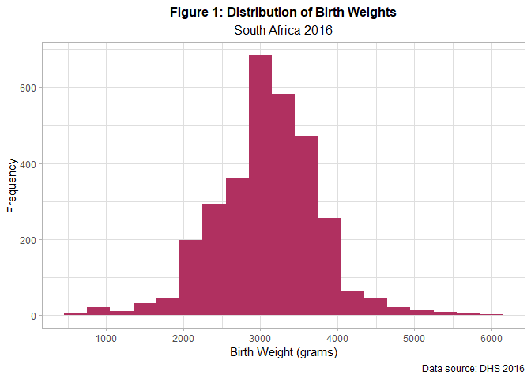

Figure 2 suggests that the birth weight of a child increased with the mother’s body mass index.

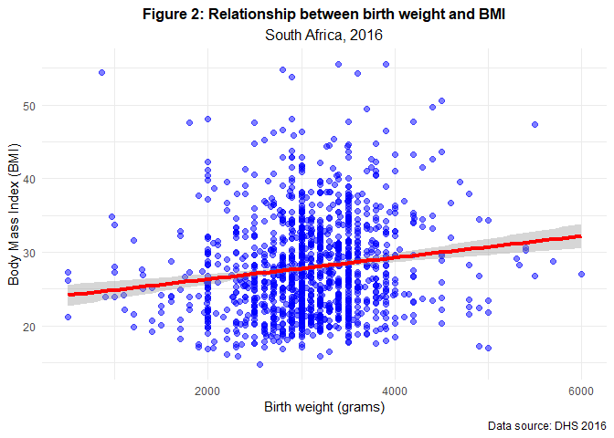

Women with primary school level had the lowest median birth weight `Figure 3`.

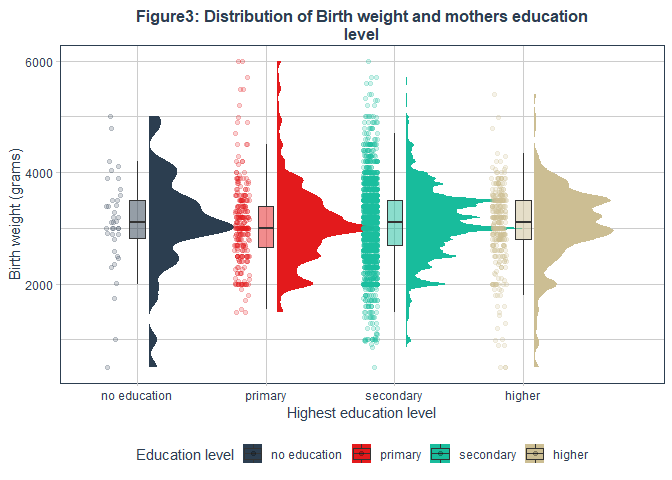

Figure 4 shows that there was not a big difference in the percentages of children with a normal birth weight by wealth index category.

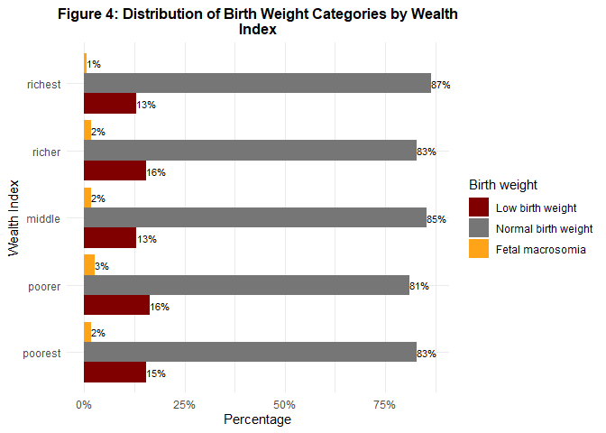

## Conclusion

Our analysis shows that the median birth weight in South Africa in 2016 was 3100. Birth weight was associated with mother’s body mass index and education level. There was no association between wealth quintile and birth weight.